# Risk Factor Analysis

## Outcome Variable

**Outcome Variable:** pers_wasted624

## Predictor Variables

**Intervention Variable:** ever_underweight06

**Adjustment Set:**

- sex
- arm
- brthmon
- vagbrth
- single
- W_mage
- W_mhtcm
- W_mwtkg
- W_mbmi
- W_meducyrs
- W_feducyrs
- W_parity
- delta_brthmon
- delta_vagbrth
- delta_single
- delta_W_mage
- delta_W_mhtcm
- delta_W_mwtkg
- delta_W_mbmi
- delta_W_meducyrs
- delta_W_feducyrs
- delta_W_parity

## Stratifying Variables

The analysis was stratified on these variable(s):

- studyid
- country

## Data Summary

| studyid | country | ever_underweight06 | pers_wasted624 | n_cell | n | outcome_variable |
| --- | --- | --- | --- | --- | --- | --- |
| ki0047075b-MAL-ED | BANGLADESH | 0 | 0 | 158 | 240 | pers_wasted624 |
| ki0047075b-MAL-ED | BANGLADESH | 0 | 1 | 3 | 240 | pers_wasted624 |
| ki0047075b-MAL-ED | BANGLADESH | 1 | 0 | 65 | 240 | pers_wasted624 |
| ki0047075b-MAL-ED | BANGLADESH | 1 | 1 | 14 | 240 | pers_wasted624 |
| ki0047075b-MAL-ED | BRAZIL | 0 | 0 | 191 | 207 | pers_wasted624 |
| ki0047075b-MAL-ED | BRAZIL | 0 | 1 | 2 | 207 | pers_wasted624 |
| ki0047075b-MAL-ED | BRAZIL | 1 | 0 | 14 | 207 | pers_wasted624 |
| ki0047075b-MAL-ED | BRAZIL | 1 | 1 | 0 | 207 | pers_wasted624 |
| ki0047075b-MAL-ED | INDIA | 0 | 0 | 133 | 235 | pers_wasted624 |
| ki0047075b-MAL-ED | INDIA | 0 | 1 | 1 | 235 | pers_wasted624 |
| ki0047075b-MAL-ED | INDIA | 1 | 0 | 74 | 235 | pers_wasted624 |
| ki0047075b-MAL-ED | INDIA | 1 | 1 | 27 | 235 | pers_wasted624 |
| ki0047075b-MAL-ED | NEPAL | 0 | 0 | 195 | 235 | pers_wasted624 |
| ki0047075b-MAL-ED | NEPAL | 0 | 1 | 0 | 235 | pers_wasted624 |
| ki0047075b-MAL-ED | NEPAL | 1 | 0 | 38 | 235 | pers_wasted624 |
| ki0047075b-MAL-ED | NEPAL | 1 | 1 | 2 | 235 | pers_wasted624 |
| ki0047075b-MAL-ED | PERU | 0 | 0 | 222 | 270 | pers_wasted624 |
| ki0047075b-MAL-ED | PERU | 0 | 1 | 1 | 270 | pers_wasted624 |
| ki0047075b-MAL-ED | PERU | 1 | 0 | 45 | 270 | pers_wasted624 |
| ki0047075b-MAL-ED | PERU | 1 | 1 | 2 | 270 | pers_wasted624 |
| ki0047075b-MAL-ED | SOUTH AFRICA | 0 | 0 | 215 | 259 | pers_wasted624 |
| ki0047075b-MAL-ED | SOUTH AFRICA | 0 | 1 | 0 | 259 | pers_wasted624 |
| ki0047075b-MAL-ED | SOUTH AFRICA | 1 | 0 | 42 | 259 | pers_wasted624 |
| ki0047075b-MAL-ED | SOUTH AFRICA | 1 | 1 | 2 | 259 | pers_wasted624 |
| ki0047075b-MAL-ED | TANZANIA, UNITED REPUBLIC OF | 0 | 0 | 203 | 245 | pers_wasted624 |
| ki0047075b-MAL-ED | TANZANIA, UNITED REPUBLIC OF | 0 | 1 | 0 | 245 | pers_wasted624 |
| ki0047075b-MAL-ED | TANZANIA, UNITED REPUBLIC OF | 1 | 0 | 42 | 245 | pers_wasted624 |
| ki0047075b-MAL-ED | TANZANIA, UNITED REPUBLIC OF | 1 | 1 | 0 | 245 | pers_wasted624 |
| ki1000108-CMC-V-BCS-2002 | INDIA | 0 | 0 | 186 | 373 | pers_wasted624 |
| ki1000108-CMC-V-BCS-2002 | INDIA | 0 | 1 | 4 | 373 | pers_wasted624 |

[output cut: 90 more lines]

The following strata were considered:

- studyid: ki0047075b-MAL-ED, country: BANGLADESH
- studyid: ki0047075b-MAL-ED, country: BRAZIL
- studyid: ki0047075b-MAL-ED, country: INDIA
- studyid: ki0047075b-MAL-ED, country: NEPAL
- studyid: ki0047075b-MAL-ED, country: PERU
- studyid: ki0047075b-MAL-ED, country: SOUTH AFRICA
- studyid: ki0047075b-MAL-ED, country: TANZANIA, UNITED REPUBLIC OF
- studyid: ki1000108-CMC-V-BCS-2002, country: INDIA
- studyid: ki1000108-IRC, country: INDIA
- studyid: ki1000109-EE, country: PAKISTAN
- studyid: ki1000109-ResPak, country: PAKISTAN
- studyid: ki1000304b-SAS-CompFeed, country: INDIA
- studyid: ki1000304b-SAS-FoodSuppl, country: INDIA
- studyid: ki1017093-NIH-Birth, country: BANGLADESH
- studyid: ki1017093b-PROVIDE, country: BANGLADESH
- studyid: ki1017093c-NIH-Crypto, country: BANGLADESH
- studyid: ki1066203-TanzaniaChild2, country: TANZANIA, UNITED REPUBLIC OF
- studyid: ki1101329-Keneba, country: GAMBIA
- studyid: ki1112895-Guatemala BSC, country: GUATEMALA
- studyid: ki1113344-GMS-Nepal, country: NEPAL
- studyid: ki1114097-CMIN, country: BANGLADESH
- studyid: ki1114097-CONTENT, country: PERU
- studyid: ki1119695-PROBIT, country: BELARUS
- studyid: ki1126311-ZVITAMBO, country: ZIMBABWE
- studyid: ki1135781-COHORTS, country: GUATEMALA
- studyid: ki1135781-COHORTS, country: INDIA
- studyid: ki1135781-COHORTS, country: PHILIPPINES
- studyid: ki1148112-LCNI-5, country: MALAWI
- studyid: kiGH5241-JiVitA-3, country: BANGLADESH
- studyid: kiGH5241-JiVitA-4, country: BANGLADESH

### Dropped Strata

Some strata were dropped due to rare outcomes:

- studyid: ki0047075b-MAL-ED, country: BANGLADESH
- studyid: ki0047075b-MAL-ED, country: BRAZIL
- studyid: ki0047075b-MAL-ED, country: INDIA
- studyid: ki0047075b-MAL-ED, country: NEPAL
- studyid: ki0047075b-MAL-ED, country: PERU
- studyid: ki0047075b-MAL-ED, country: SOUTH AFRICA
- studyid: ki0047075b-MAL-ED, country: TANZANIA, UNITED REPUBLIC OF
- studyid: ki1000108-CMC-V-BCS-2002, country: INDIA
- studyid: ki1000109-EE, country: PAKISTAN
- studyid: ki1112895-Guatemala BSC, country: GUATEMALA
- studyid: ki1114097-CMIN, country: BANGLADESH
- studyid: ki1114097-CONTENT, country: PERU
- studyid: ki1135781-COHORTS, country: GUATEMALA
- studyid: ki1148112-LCNI-5, country: MALAWI

## Methods Detail

We’re interested in the causal parameters $E[Y_a]$ for all values of $a \in \mathcal{A}$. These parameters represent the mean outcome if, possibly contrary to fact, we intervened to set all units to have $A=a$. Under the randomization and positivity assumptions, these are identified by the statistical parameters $\psi_a=E_W[E_{Y|A,W}(Y|A=a,W)]$. In addition, we’re interested in the mean of $Y$, $E[Y]$ under no intervention (the observed mean). We will estimate these parameters by using SuperLearner to fit the relevant likelihood factors – $E_{Y|A,W}(Y|A=a,W)$ and $p(A=a|W)$, and then updating our likelihood fit using a joint TMLE.

For unadjusted analyses ($W=\{\}$), initial likelihoods were estimated using Lrnr_glm to estimate the simple $E(Y|A)$ and Lrnr_mean to estimate $p(A)$. For adjusted analyses, a small library containing Lrnr_glmnet, Lrnr_xgboost, and Lrnr_mean was used.

Having estimated these parameters, we will then use the delta method to estimate relative risks and attributable risks relative to a prespecified baseline level of $A$.

# Results Detail

## Results Plots

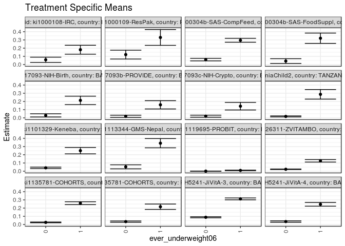

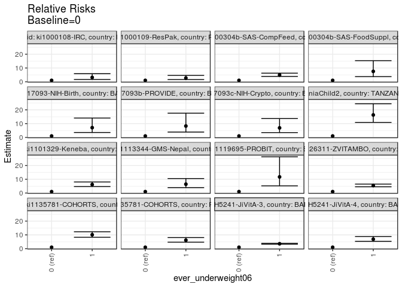

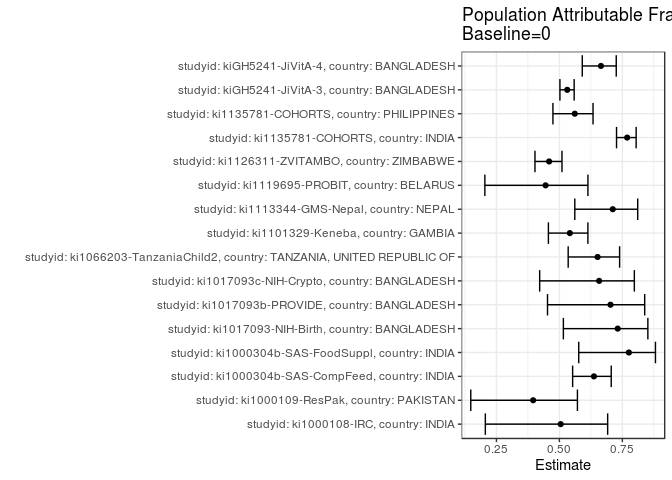

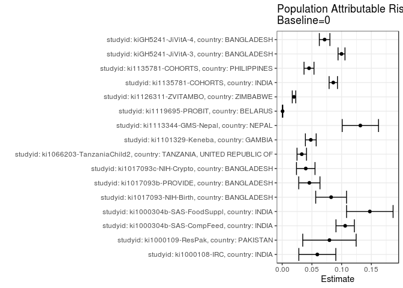

## Results Table

### Parameter: TSM

| studyid | country | intervention_level | baseline_level | estimate | ci_lower | ci_upper |
| --- | --- | --- | --- | --- | --- | --- |
| ki1000108-IRC | INDIA | 0 | NA | 0.0579319 | 0.0260125 | 0.0898513 |
| ki1000108-IRC | INDIA | 1 | NA | 0.1806852 | 0.1263927 | 0.2349777 |
| ki1000109-ResPak | PAKISTAN | 0 | NA | 0.1213380 | 0.0673823 | 0.1752938 |
| ki1000109-ResPak | PAKISTAN | 1 | NA | 0.3300377 | 0.2338617 | 0.4262138 |
| ki1000304b-SAS-CompFeed | INDIA | 0 | NA | 0.0603340 | 0.0448969 | 0.0757711 |
| ki1000304b-SAS-CompFeed | INDIA | 1 | NA | 0.2960405 | 0.2720234 | 0.3200576 |
| ki1000304b-SAS-FoodSuppl | INDIA | 0 | NA | 0.0425532 | 0.0136640 | 0.0714424 |
| ki1000304b-SAS-FoodSuppl | INDIA | 1 | NA | 0.3207547 | 0.2578442 | 0.3836653 |
| ki1017093-NIH-Birth | BANGLADESH | 0 | NA | 0.0302013 | 0.0107524 | 0.0496502 |
| ki1017093-NIH-Birth | BANGLADESH | 1 | NA | 0.2131148 | 0.1616847 | 0.2645448 |
| ki1017093b-PROVIDE | BANGLADESH | 0 | NA | 0.0193237 | 0.0060525 | 0.0325948 |
| ki1017093b-PROVIDE | BANGLADESH | 1 | NA | 0.1592040 | 0.1085836 | 0.2098244 |
| ki1017093c-NIH-Crypto | BANGLADESH | 0 | NA | 0.0206206 | 0.0082207 | 0.0330205 |
| ki1017093c-NIH-Crypto | BANGLADESH | 1 | NA | 0.1422397 | 0.0961345 | 0.1883450 |
| ki1066203-TanzaniaChild2 | TANZANIA, UNITED REPUBLIC OF | 0 | NA | 0.0176066 | 0.0114636 | 0.0237497 |
| ki1066203-TanzaniaChild2 | TANZANIA, UNITED REPUBLIC OF | 1 | NA | 0.2868058 | 0.2285389 | 0.3450726 |
| ki1101329-Keneba | GAMBIA | 0 | NA | 0.0407633 | 0.0319463 | 0.0495804 |
| ki1101329-Keneba | GAMBIA | 1 | NA | 0.2500553 | 0.2111226 | 0.2889879 |
| ki1113344-GMS-Nepal | NEPAL | 0 | NA | 0.0532103 | 0.0285043 | 0.0779162 |
| ki1113344-GMS-Nepal | NEPAL | 1 | NA | 0.3411722 | 0.2846543 | 0.3976900 |
| ki1119695-PROBIT | BELARUS | 0 | NA | 0.0008023 | 0.0000534 | 0.0015512 |
| ki1119695-PROBIT | BELARUS | 1 | NA | 0.0093767 | 0.0053896 | 0.0133639 |
| ki1126311-ZVITAMBO | ZIMBABWE | 0 | NA | 0.0234001 | 0.0202711 | 0.0265291 |
| ki1126311-ZVITAMBO | ZIMBABWE | 1 | NA | 0.1264077 | 0.1111733 | 0.1416421 |
| ki1135781-COHORTS | INDIA | 0 | NA | 0.0258123 | 0.0210908 | 0.0305338 |
| ki1135781-COHORTS | INDIA | 1 | NA | 0.2598421 | 0.2421636 | 0.2775206 |
| ki1135781-COHORTS | PHILIPPINES | 0 | NA | 0.0353089 | 0.0274515 | 0.0431663 |
| ki1135781-COHORTS | PHILIPPINES | 1 | NA | 0.2166949 | 0.1839096 | 0.2494802 |
| kiGH5241-JiVitA-3 | BANGLADESH | 0 | NA | 0.0880859 | 0.0815258 | 0.0946460 |
| kiGH5241-JiVitA-3 | BANGLADESH | 1 | NA | 0.3120577 | 0.3008367 | 0.3232787 |
| kiGH5241-JiVitA-4 | BANGLADESH | 0 | NA | 0.0359586 | 0.0274258 | 0.0444914 |
| kiGH5241-JiVitA-4 | BANGLADESH | 1 | NA | 0.2461591 | 0.2233009 | 0.2690173 |

### Parameter: E(Y)

| studyid | country | intervention_level | baseline_level | estimate | ci_lower | ci_upper |
| --- | --- | --- | --- | --- | --- | --- |
| ki1000108-IRC | INDIA | NA | NA | 0.1170732 | 0.0859146 | 0.1482317 |
| ki1000109-ResPak | PAKISTAN | NA | NA | 0.2008547 | 0.1494120 | 0.2522974 |
| ki1000304b-SAS-CompFeed | INDIA | NA | NA | 0.1663067 | 0.1478935 | 0.1847199 |
| ki1000304b-SAS-FoodSuppl | INDIA | NA | NA | 0.1900000 | 0.1515071 | 0.2284929 |
| ki1017093-NIH-Birth | BANGLADESH | NA | NA | 0.1125461 | 0.0859151 | 0.1391771 |
| ki1017093b-PROVIDE | BANGLADESH | NA | NA | 0.0650407 | 0.0455353 | 0.0845460 |
| ki1017093c-NIH-Crypto | BANGLADESH | NA | NA | 0.0602740 | 0.0429977 | 0.0775502 |
| ki1066203-TanzaniaChild2 | TANZANIA, UNITED REPUBLIC OF | NA | NA | 0.0505451 | 0.0409848 | 0.0601054 |
| ki1101329-Keneba | GAMBIA | NA | NA | 0.0888980 | 0.0776057 | 0.1001903 |
| ki1113344-GMS-Nepal | NEPAL | NA | NA | 0.1847458 | 0.1534039 | 0.2160876 |
| ki1119695-PROBIT | BELARUS | NA | NA | 0.0014461 | 0.0004206 | 0.0024716 |
| ki1126311-ZVITAMBO | ZIMBABWE | NA | NA | 0.0432772 | 0.0394419 | 0.0471125 |
| ki1135781-COHORTS | INDIA | NA | NA | 0.1117877 | 0.1043506 | 0.1192249 |
| ki1135781-COHORTS | PHILIPPINES | NA | NA | 0.0804557 | 0.0703953 | 0.0905161 |
| kiGH5241-JiVitA-3 | BANGLADESH | NA | NA | 0.1879125 | 0.1813641 | 0.1944608 |
| kiGH5241-JiVitA-4 | BANGLADESH | NA | NA | 0.1073532 | 0.0971813 | 0.1175251 |

### Parameter: RR

| studyid | country | intervention_level | baseline_level | estimate | ci_lower | ci_upper |
| --- | --- | --- | --- | --- | --- | --- |
| ki1000108-IRC | INDIA | 0 | 0 | 1.000000 | 1.000000 | 1.000000 |
| ki1000108-IRC | INDIA | 1 | 0 | 3.118924 | 1.662980 | 5.849554 |
| ki1000109-ResPak | PAKISTAN | 0 | 0 | 1.000000 | 1.000000 | 1.000000 |
| ki1000109-ResPak | PAKISTAN | 1 | 0 | 2.719986 | 1.600848 | 4.621501 |
| ki1000304b-SAS-CompFeed | INDIA | 0 | 0 | 1.000000 | 1.000000 | 1.000000 |
| ki1000304b-SAS-CompFeed | INDIA | 1 | 0 | 4.906696 | 3.860396 | 6.236578 |
| ki1000304b-SAS-FoodSuppl | INDIA | 0 | 0 | 1.000000 | 1.000000 | 1.000000 |
| ki1000304b-SAS-FoodSuppl | INDIA | 1 | 0 | 7.537735 | 3.718279 | 15.280577 |
| ki1017093-NIH-Birth | BANGLADESH | 0 | 0 | 1.000000 | 1.000000 | 1.000000 |
| ki1017093-NIH-Birth | BANGLADESH | 1 | 0 | 7.056466 | 3.547479 | 14.036366 |
| ki1017093b-PROVIDE | BANGLADESH | 0 | 0 | 1.000000 | 1.000000 | 1.000000 |
| ki1017093b-PROVIDE | BANGLADESH | 1 | 0 | 8.238806 | 3.865305 | 17.560819 |
| ki1017093c-NIH-Crypto | BANGLADESH | 0 | 0 | 1.000000 | 1.000000 | 1.000000 |
| ki1017093c-NIH-Crypto | BANGLADESH | 1 | 0 | 6.897949 | 3.483658 | 13.658546 |
| ki1066203-TanzaniaChild2 | TANZANIA, UNITED REPUBLIC OF | 0 | 0 | 1.000000 | 1.000000 | 1.000000 |
| ki1066203-TanzaniaChild2 | TANZANIA, UNITED REPUBLIC OF | 1 | 0 | 16.289652 | 10.876118 | 24.397744 |
| ki1101329-Keneba | GAMBIA | 0 | 0 | 1.000000 | 1.000000 | 1.000000 |
| ki1101329-Keneba | GAMBIA | 1 | 0 | 6.134318 | 4.700541 | 8.005431 |
| ki1113344-GMS-Nepal | NEPAL | 0 | 0 | 1.000000 | 1.000000 | 1.000000 |
| ki1113344-GMS-Nepal | NEPAL | 1 | 0 | 6.411773 | 3.917447 | 10.494291 |
| ki1119695-PROBIT | BELARUS | 0 | 0 | 1.000000 | 1.000000 | 1.000000 |
| ki1119695-PROBIT | BELARUS | 1 | 0 | 11.687611 | 5.203168 | 26.253286 |
| ki1126311-ZVITAMBO | ZIMBABWE | 0 | 0 | 1.000000 | 1.000000 | 1.000000 |
| ki1126311-ZVITAMBO | ZIMBABWE | 1 | 0 | 5.402019 | 4.512939 | 6.466253 |
| ki1135781-COHORTS | INDIA | 0 | 0 | 1.000000 | 1.000000 | 1.000000 |
| ki1135781-COHORTS | INDIA | 1 | 0 | 10.066587 | 8.282881 | 12.234412 |
| ki1135781-COHORTS | PHILIPPINES | 0 | 0 | 1.000000 | 1.000000 | 1.000000 |
| ki1135781-COHORTS | PHILIPPINES | 1 | 0 | 6.137117 | 4.691332 | 8.028468 |
| kiGH5241-JiVitA-3 | BANGLADESH | 0 | 0 | 1.000000 | 1.000000 | 1.000000 |
| kiGH5241-JiVitA-3 | BANGLADESH | 1 | 0 | 3.542653 | 3.266352 | 3.842326 |
| kiGH5241-JiVitA-4 | BANGLADESH | 0 | 0 | 1.000000 | 1.000000 | 1.000000 |
| kiGH5241-JiVitA-4 | BANGLADESH | 1 | 0 | 6.845628 | 5.318778 | 8.810788 |

### Parameter: PAR

| studyid | country | intervention_level | baseline_level | estimate | ci_lower | ci_upper |
| --- | --- | --- | --- | --- | --- | --- |
| ki1000108-IRC | INDIA | 0 | NA | 0.0591413 | 0.0280396 | 0.0902429 |
| ki1000109-ResPak | PAKISTAN | 0 | NA | 0.0795167 | 0.0345856 | 0.1244477 |
| ki1000304b-SAS-CompFeed | INDIA | 0 | NA | 0.1059727 | 0.0905171 | 0.1214284 |
| ki1000304b-SAS-FoodSuppl | INDIA | 0 | NA | 0.1474468 | 0.1083088 | 0.1865848 |
| ki1017093-NIH-Birth | BANGLADESH | 0 | NA | 0.0823448 | 0.0564310 | 0.1082586 |
| ki1017093b-PROVIDE | BANGLADESH | 0 | NA | 0.0457170 | 0.0278436 | 0.0635904 |
| ki1017093c-NIH-Crypto | BANGLADESH | 0 | NA | 0.0396534 | 0.0240583 | 0.0552484 |
| ki1066203-TanzaniaChild2 | TANZANIA, UNITED REPUBLIC OF | 0 | NA | 0.0329385 | 0.0249813 | 0.0408956 |
| ki1101329-Keneba | GAMBIA | 0 | NA | 0.0481347 | 0.0390665 | 0.0572029 |
| ki1113344-GMS-Nepal | NEPAL | 0 | NA | 0.1315355 | 0.1009869 | 0.1620841 |
| ki1119695-PROBIT | BELARUS | 0 | NA | 0.0006439 | 0.0002324 | 0.0010553 |
| ki1126311-ZVITAMBO | ZIMBABWE | 0 | NA | 0.0198771 | 0.0169856 | 0.0227687 |
| ki1135781-COHORTS | INDIA | 0 | NA | 0.0859754 | 0.0789374 | 0.0930134 |
| ki1135781-COHORTS | PHILIPPINES | 0 | NA | 0.0451468 | 0.0367585 | 0.0535350 |
| kiGH5241-JiVitA-3 | BANGLADESH | 0 | NA | 0.0998266 | 0.0939779 | 0.1056752 |
| kiGH5241-JiVitA-4 | BANGLADESH | 0 | NA | 0.0713946 | 0.0625245 | 0.0802648 |

### Parameter: PAF

| studyid | country | intervention_level | baseline_level | estimate | ci_lower | ci_upper |
| --- | --- | --- | --- | --- | --- | --- |
| ki1000108-IRC | INDIA | 0 | NA | 0.5051651 | 0.2059379 | 0.6916342 |
| ki1000109-ResPak | PAKISTAN | 0 | NA | 0.3958915 | 0.1481144 | 0.5716008 |
| ki1000304b-SAS-CompFeed | INDIA | 0 | NA | 0.6372126 | 0.5525539 | 0.7058535 |
| ki1000304b-SAS-FoodSuppl | INDIA | 0 | NA | 0.7760358 | 0.5768128 | 0.8814710 |
| ki1017093-NIH-Birth | BANGLADESH | 0 | NA | 0.7316536 | 0.5158152 | 0.8512763 |
| ki1017093b-PROVIDE | BANGLADESH | 0 | NA | 0.7028985 | 0.4528294 | 0.8386805 |
| ki1017093c-NIH-Crypto | BANGLADESH | 0 | NA | 0.6578857 | 0.4216911 | 0.7976131 |
| ki1066203-TanzaniaChild2 | TANZANIA, UNITED REPUBLIC OF | 0 | NA | 0.6516650 | 0.5349188 | 0.7391053 |
| ki1101329-Keneba | GAMBIA | 0 | NA | 0.5414594 | 0.4563759 | 0.6132264 |
| ki1113344-GMS-Nepal | NEPAL | 0 | NA | 0.7119811 | 0.5611889 | 0.8109554 |
| ki1119695-PROBIT | BELARUS | 0 | NA | 0.4452229 | 0.2040829 | 0.6133044 |
| ki1126311-ZVITAMBO | ZIMBABWE | 0 | NA | 0.4592979 | 0.4030393 | 0.5102546 |
| ki1135781-COHORTS | INDIA | 0 | NA | 0.7690951 | 0.7269091 | 0.8047644 |
| ki1135781-COHORTS | PHILIPPINES | 0 | NA | 0.5611384 | 0.4743469 | 0.6335996 |
| kiGH5241-JiVitA-3 | BANGLADESH | 0 | NA | 0.5312398 | 0.5021011 | 0.5586733 |
| kiGH5241-JiVitA-4 | BANGLADESH | 0 | NA | 0.6650443 | 0.5908794 | 0.7257646 |